# Project 2

Viviantsui0514,Zoey Han,FUHUNG

2018年5月15日

```r
library(data.table)
library(dplyr)
library(tidyr)
```

# 匯入資料

- 使用fread匯入大量資料

```r
path <- "C:\\Users\\FuHung\\Documents\\GitHub\\CSX-DataScience\\Kaggle Presentation"

aisles <- fread(file.path(path, "aisles.csv"))
departments <- fread(file.path(path, "departments.csv"))
orderp <- fread(file.path(path, "order_products__prior.csv"))
ordert <- fread(file.path(path, "order_products__train.csv"))
orders <- fread(file.path(path, "orders.csv"))
products <- fread(file.path(path, "products.csv"))
```

- 將資料型態轉為factor

```r
aisles$aisle <- as.factor(aisles$aisle)
departments$department <- as.factor(departments$department)
orders$eval_set <- as.factor(orders$eval_set)
products$product_name <- as.factor(products$product_name)
```

# 觀察資料

- Aisles

```r
head(aisles)
```

```
##    aisle_id                      aisle
## 1:        1      prepared soups salads
## 2:        2          specialty cheeses
## 3:        3        energy granola bars
## 4:        4              instant foods
## 5:        5 marinades meat preparation
## 6:        6                      other
```

- Departments

```r
head(departments)
```

```
##    department_id    department
## 1:             1        frozen
## 2:             2         other
## 3:             3        bakery
## 4:             4       produce
## 5:             5       alcohol
## 6:             6 international
```

- Orderp (prior)

```r
head(orderp)
```

```
##    order_id product_id add_to_cart_order reordered
## 1:        2      33120                 1         1
## 2:        2      28985                 2         1
## 3:        2       9327                 3         0
## 4:        2      45918                 4         1
## 5:        2      30035                 5         0
## 6:        2      17794                 6         1
```

- Ordert (train)

```r
head(ordert)
```

```
##    order_id product_id add_to_cart_order reordered
## 1:        1      49302                 1         1
## 2:        1      11109                 2         1
## 3:        1      10246                 3         0
## 4:        1      49683                 4         0
## 5:        1      43633                 5         1
## 6:        1      13176                 6         0
```

- Orders > order_dow is the day of week.

```r
head(orders)
```

```
##    order_id user_id eval_set order_number order_dow order_hour_of_day
## 1:  2539329       1    prior            1         2                 8
## 2:  2398795       1    prior            2         3                 7
## 3:   473747       1    prior            3         3                12
## 4:  2254736       1    prior            4         4                 7
## 5:   431534       1    prior            5         4                15
## 6:  3367565       1    prior            6         2                 7
##    days_since_prior_order
## 1:                     NA
## 2:                     15
## 3:                     21
## 4:                     29
## 5:                     28
## 6:                     19
```

- Products

```r
head(products)
```

```
##    product_id
## 1:          1
## 2:          2
## 3:          3
## 4:          4
## 5:          5
## 6:          6
##                                                         product_name
## 1:                                        Chocolate Sandwich Cookies
## 2:                                                  All-Seasons Salt
## 3:                              Robust Golden Unsweetened Oolong Tea
## 4: Smart Ones Classic Favorites Mini Rigatoni With Vodka Cream Sauce
## 5:                                         Green Chile Anytime Sauce
## 6:                                                      Dry Nose Oil
##    aisle_id department_id
## 1:       61            19
## 2:      104            13
## 3:       94             7
## 4:       38             1
## 5:        5            13
## 6:       11            11
```

# 產品

- 將product對應的aisles和department的id用名稱替換

```r
library(magrittr)
products <- products %>%
  inner_join(aisles) %>% inner_join(departments) %>%
  select(-aisle_id, -department_id)
rm(aisles, departments)
```

```r
head(products)
```

```
##   product_id
## 1          1
## 2          2
## 3          3
## 4          4
## 5          5
## 6          6
##                                                        product_name
## 1                                        Chocolate Sandwich Cookies
## 2                                                  All-Seasons Salt
## 3                              Robust Golden Unsweetened Oolong Tea
## 4 Smart Ones Classic Favorites Mini Rigatoni With Vodka Cream Sauce
## 5                                         Green Chile Anytime Sauce
## 6                                                      Dry Nose Oil
##                        aisle    department
## 1              cookies cakes        snacks
## 2          spices seasonings        pantry
## 3                        tea     beverages
## 4               frozen meals        frozen
## 5 marinades meat preparation        pantry
## 6           cold flu allergy personal care
```

```r
ordert$user_id <- orders$user_id[match(ordert$order_id, orders$order_id)]
orders_products <- orders %>% inner_join(orderp, by = "order_id")
head(orders_products)
```

```
##   order_id user_id eval_set order_number order_dow order_hour_of_day
## 1  2539329       1    prior            1         2                 8
## 2  2539329       1    prior            1         2                 8
## 3  2539329       1    prior            1         2                 8
## 4  2539329       1    prior            1         2                 8
## 5  2539329       1    prior            1         2                 8
## 6  2398795       1    prior            2         3                 7
##   days_since_prior_order product_id add_to_cart_order reordered
## 1                     NA        196                 1         0
## 2                     NA      14084                 2         0
## 3                     NA      12427                 3         0
## 4                     NA      26088                 4         0
## 5                     NA      26405                 5         0
## 6                     15        196                 1         1
```

- 清除orderp和不用的資料

```r
rm(orderp)
gc()
```

```
##             used   (Mb) gc trigger   (Mb)  max used   (Mb)
## Ncells    680364   36.4    1221601   65.3   1221601   65.3
## Vcells 207191102 1580.8  328585128 2507.0 272142658 2076.3
```

- 整理產品資料
1. prod_first_orders (某user的第一筆訂單)
2. prod_second_orders (某user的第二筆訂單)
3. prod_orders = prod_first_orders + prod_reorders

```r
memory.limit(size=10000)
```

```
## [1] 10000
```

```r
prd <- orders_products %>%
  arrange(user_id, order_number, product_id) %>%
  group_by(user_id, product_id) %>%
  mutate(product_time = row_number()) %>%
  ungroup() %>%
  group_by(product_id) %>%
  summarise(
    prod_orders = n(),
    prod_reorders = sum(reordered),
    prod_first_orders = sum(product_time == 1),
    prod_second_orders = sum(product_time == 2)
  )
head(prd)
```

```
## # A tibble: 6 x 5
##   product_id prod_orders prod_reorders prod_first_orders prod_second_orde~
##        <int>       <int>         <int>             <int>             <int>
## 1          1        1852          1136               716               276
## 2          2          90            12                78                 8
## 3          3         277           203                74                36
## 4          4         329           147               182                64
## 5          5          15             9                 6                 4
## 6          6           8             3                 5                 2
```

- 計算產品資料
1. 同一個人reorder這項產品的機率
2. 期望的reorder次數
3. Reorder佔總order比例

```r
prd$prod_reorder_probability <- prd$prod_second_orders / prd$prod_first_orders

prd$prod_reorder_times <- 1 + prd$prod_reorders / prd$prod_first_orders

prd$prod_reorder_ratio <- prd$prod_reorders / prd$prod_orders

prd <- prd %>% select(-prod_reorders, -prod_first_orders, -prod_second_orders)
head(prd)
```

```
## # A tibble: 6 x 5
##   product_id prod_orders prod_reorder_probability prod_reorder_times
##        <int>       <int>                    <dbl>              <dbl>
## 1          1        1852                    0.385               2.59
## 2          2          90                    0.103               1.15
## 3          3         277                    0.486               3.74
## 4          4         329                    0.352               1.81
## 5          5          15                    0.667               2.5
## 6          6           8                    0.4                 1.6
## # ... with 1 more variable: prod_reorder_ratio <dbl>
```

- 清除products和不用的資料

```r
rm(products)
gc()
```

```
##             used   (Mb) gc trigger   (Mb)  max used   (Mb)
## Ncells    665378   35.6   23672465 1264.3  29590582 1580.4
## Vcells 207025328 1579.5  588955302 4493.4 508596499 3880.3
```

# 消費者

- 整理消費者資料
1. user_orders 該用戶總訂單
2. user_period 該用戶從第一筆訂單到最後一筆訂單總時長
3. user_mean_days_prior_order 兩筆訂單平均間隔

```r
users <- orders %>%
  filter(eval_set == "prior") %>%
  group_by(user_id) %>%
  summarise(
    user_orders = max(order_number),
    user_period = sum(days_since_prior_order, na.rm = T),
    user_mean_days_since_prior = mean(days_since_prior_order, na.rm = T)
  )
head(users)
```

```
## # A tibble: 6 x 4
##   user_id user_orders user_period user_mean_days_since_prior
##     <int>       <dbl>       <dbl>                      <dbl>
## 1       1          10         176                       19.6
## 2       2          14         198                       15.2
## 3       3          12         133                       12.1
## 4       4           5          55                       13.8
## 5       5           4          40                       13.3
## 6       6           3          18                        9
```

- 整理消費者購買產品資料
1. 總購買產品數
2. reorder時再次購買該件商品的機率
3. 購買的產品種類數

```r
us <- orders_products %>%
  group_by(user_id) %>%
  summarise(
    user_total_products = n(),
    user_reorder_ratio = sum(reordered == 1) / sum(order_number > 1),
    user_distinct_products = n_distinct(product_id)
  )
head(us)
```

```
## # A tibble: 6 x 4
##   user_id user_total_products user_reorder_ratio user_distinct_products
##     <int>               <int>              <dbl>                  <int>
## 1       1                  59             0.759                      18
## 2       2                 195             0.511                     102
## 3       3                  88             0.705                      33
## 4       4                  18             0.0714                     17
## 5       5                  37             0.538                      23
## 6       6                  14             0.2                        12
```

```r
users <- users %>% inner_join(us)
users$user_average_basket <- users$user_total_products / users$user_orders

us <- orders %>%
  filter(eval_set != "prior") %>%
  select(user_id, order_id, eval_set,
         time_since_last_order = days_since_prior_order)

users <- users %>% inner_join(us)
head(users)
```

```
## # A tibble: 6 x 11
##   user_id user_orders user_period user_mean_days_since_~ user_total_produ~
##     <int>       <dbl>       <dbl>                  <dbl>             <int>
## 1       1          10         176                   19.6                59
## 2       2          14         198                   15.2               195
## 3       3          12         133                   12.1                88
## 4       4           5          55                   13.8                18
## 5       5           4          40                   13.3                37
## 6       6           3          18                    9                  14
## # ... with 6 more variables: user_reorder_ratio <dbl>,
## #   user_distinct_products <int>, user_average_basket <dbl>,
## #   order_id <int>, eval_set <fct>, time_since_last_order <dbl>
```

```r
rm(us)
gc()
```

```
##             used   (Mb) gc trigger   (Mb)  max used   (Mb)
## Ncells    666608   35.7   18937972 1011.4  29590582 1580.4
## Vcells 208781333 1592.9  588955302 4493.4 508596499 3880.3
```

# Database

```r
data <- orders_products %>%
  group_by(user_id, product_id) %>%
  summarise(
    up_orders = n(),#某用戶購買該產品的次數
    up_first_order = min(order_number),#第幾筆訂單中首次出現該產品
    up_last_order = max(order_number),#第幾筆訂單中最後一次出現該產品
    up_average_cart_position = mean(add_to_cart_order))#平均購物車位置

rm(orders_products, orders)

data <- data %>%
  inner_join(prd, by = "product_id") %>%
  inner_join(users, by = "user_id")

data$up_order_rate <- data$up_orders / data$user_orders#該用戶訂單包含該產品的機率
data$up_orders_since_last_order <- data$user_orders - data$up_last_order#最後一次購買該產品後的新訂單數
data$up_order_rate_since_first_order <- data$up_orders / (data$user_orders - data$up_first_order + 1)#首次購買該產品後該用戶訂單包含該產品的機率

data <- data %>%
  left_join(ordert %>% select(user_id, product_id, reordered),
            by = c("user_id", "product_id"))

rm(ordert, prd, users)
gc()
```

```
##             used   (Mb) gc trigger   (Mb)  max used   (Mb)
## Ncells    667016   35.7    9696240  517.9  29590582 1580.4
## Vcells 270799374 2066.1  706826362 5392.7 588950145 4493.4
```

# Train/Test dataset

```r
train <- as.data.frame(data[data$eval_set == "train",])
train$eval_set <- NULL
train$user_id <- NULL
train$product_id <- NULL
train$order_id <- NULL
train$reordered[is.na(train$reordered)] <- 0

test <- as.data.frame(data[data$eval_set == "test",])
test$eval_set <- NULL
test$user_id <- NULL
test$reordered <- NULL

rm(data)
gc()
```

```
##             used   (Mb) gc trigger   (Mb)  max used   (Mb)
## Ncells    667197   35.7    7756992  414.3  29590582 1580.4
## Vcells 250835265 1913.8  706826362 5392.7 706826306 5392.7
```

```r
head(train)
```

```
##   up_orders up_first_order up_last_order up_average_cart_position
## 1        10              1            10                 1.400000
## 2         9              2            10                 3.333333
## 3         1              5             5                 5.000000
## 4        10              1            10                 3.300000
## 5         3              2            10                 6.333333
## 6         2              2             5                 6.000000
##   prod_orders prod_reorder_probability prod_reorder_times
## 1       35791                0.5825000           4.473875
## 2        1946                0.5529623           3.493716
## 3        5526                0.5215809           2.873635
## 4        6476                0.5294818           3.857058
## 5        3751                0.4797823           2.916796
## 6      379450                0.7118844           5.972111
##   prod_reorder_ratio user_orders user_period user_mean_days_since_prior
```

[output cut: 27 more lines]

# Model

```r
library(xgboost)
```

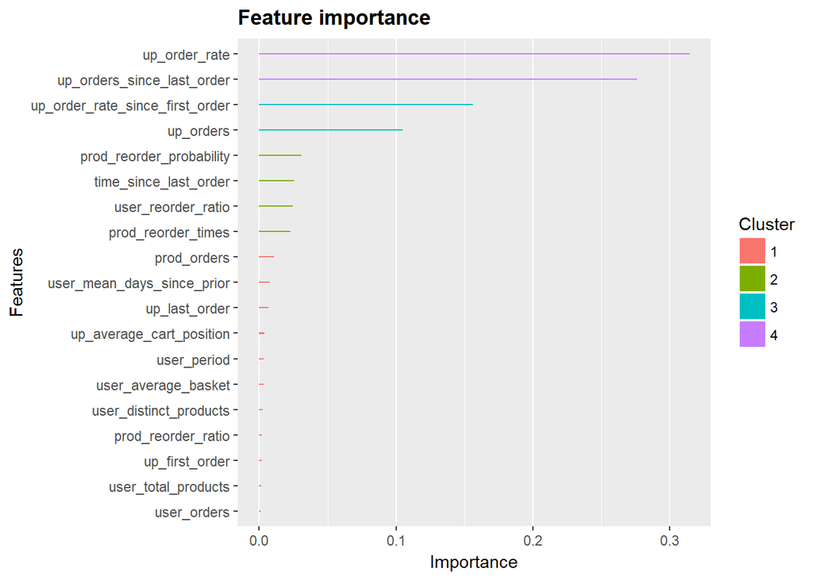

```r
library(ggplot2)
library(Ckmeans.1d.dp)
params <- list(
  "objective"           = "reg:logistic",
  "eval_metric"         = "logloss",
  "eta"                 = 0.1,
  "max_depth"           = 6,
  "min_child_weight"    = 10,
  "gamma"               = 0.70,
  "subsample"           = 0.76,
  "colsample_bytree"    = 0.95,
  "alpha"               = 2e-05,
  "lambda"              = 10
)

subtrain <- train %>% sample_frac(0.1)#抽出10%資料
X <- xgb.DMatrix(as.matrix(subtrain %>% select(-reordered)), label = subtrain$reordered)#train會不會reorder
model <- xgboost(data = X, params = params, nrounds = 80)
importance <- xgb.importance(colnames(X), model = model)
xgb.ggplot.importance(importance)
```

```r
rm(X, importance, subtrain)
gc()
```

```
##             used   (Mb) gc trigger   (Mb)  max used   (Mb)
## Ncells   1861981   99.5    6205593  331.5  29590582 1580.4
## Vcells 252989774 1930.2  706826362 5392.7 706826306 5392.7
```

1)up_order_rate:該用戶訂單包含該產品的機率  
2)up_orders_since_last_order:最後一次購買該產品後的新訂單數  
3)up_order_rate_since_first_order:首次購買該產品後該用戶訂單包含該產品的機率  
4)up_orders:某用戶購買該產品的次數  
5)prod_reorder_probability:第二次order/第一次order

# Apply model

```r
X <- xgb.DMatrix(as.matrix(test %>% select(-order_id, -product_id)))
test$reordered <- predict(model, X)

test$reordered <- (test$reordered > 0.21) * 1

submission <- test %>%
  filter(reordered == 1) %>%
  group_by(order_id) %>%
  summarise(
    products = paste(product_id, collapse = " ")
  )

missing <- data.frame(
  order_id = unique(test$order_id[!test$order_id %in% submission$order_id]),
  products = "None"
)

submission <- submission %>% bind_rows(missing) %>% arrange(order_id)
write.csv(submission, file = "submit.csv", row.names = F)
head(submission)
```

```
## # A tibble: 6 x 2
##   order_id products
##      <int> <chr>
## 1       17 13107 21463
## 2       34 2596 16083 21137 39180 39475 43504 44663 47766 47792
## 3      137 2326 5134 23794 24852 25890 38689 41787
## 4      182 5479 9337 11520 13629 32109 33000 39275 41149 47209 47672
## 5      257 13870 24838 24852 27104 27966 29837 30233 37646 39475 45013 49~
## 6      313 12779 13198 14077 21903 25890 28535 30391 45007 46906
```